# R and ggplot2

# Note for Databases and *dplyr*

- In these examples *t* is a data frame
  - In memory
- *dplyr* also works with databases
  - A reference to a table on disk, not in memory
  - Data are only copied into *R* on demand
  - Operate on Giga-/Tera-/Petabytes of data with *R*
- Lazy evalulation (or demand-driven)
  - Others: *Haskell*, *Spark*, *Dask*, *VTK*, etc.
  - Execution only happens when data are needed, like viewing or plotting

# Group By and Summaries

- `group_by` for `summarize`-ing (windowing) functions
  - min, max, average, etc.
  - *SQL* has these too

```r
# what's the average hp for each cylinder size?
t %>%
  group_by(cyl) %>%
  summarize(mean_hp = mean(hp))
```

| cyl | mean_hp |
| --- | --- |
| 4 | 82.63636 |
| 6 | 122.28571 |
| 8 | 209.21429 |

# Sorting

- Sorting, `arrange`, is useful for line plots
  - *ORDER BY* in *SQL*

```r
# get cars with displacement < 100, and order by horsepower
t %>%
  filter(disp < 100) %>%
  select(name, hp, mpg) %>%
  arrange(hp)
```

| name | hp | mpg |
| --- | --- | --- |
| Honda Civic | 52 | 30.4 |
| Toyota Corolla | 65 | 33.9 |
| Fiat 128 | 66 | 32.4 |
| Fiat X1-9 | 66 | 27.3 |
| Lotus Europa | 113 | 30.4 |

# Plotting with ggplot2

- Created by Hadley Wickham
  - Any many other libraries, *dplyr* for example (*tidyverse*)
  - Inspired by “Grammar of Graphics” by Leland Wilkinson
- Works seamlessly with *dplyr*
  - Follows the data flow graph/piping paradigm
  - Pipe your data from *dplyr* directly into a plot
- Transformers/Operators manipulate the plot

# ggplot2 example

- *t* is filtered
- Then, “piped” directly into *ggplot*
  - *aes* and *geom_point* are operators on the plot
  - `+` is the “pipe” in *ggplot2*

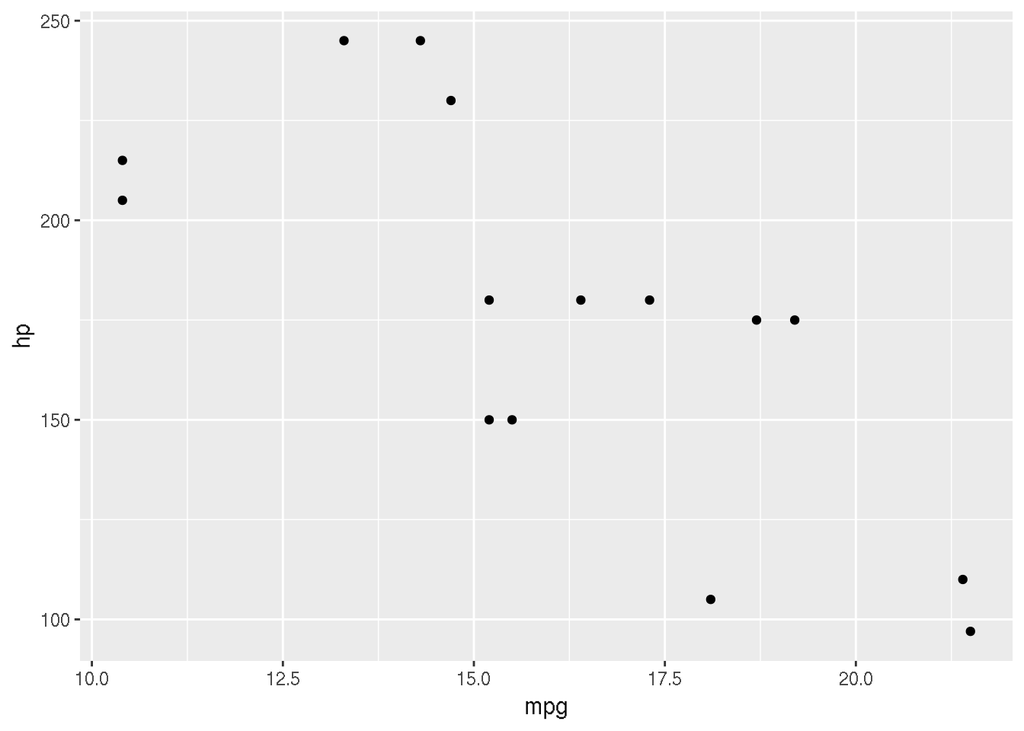

```r
library(ggplot2)

# plot 3 gear cars, mpg vs. hp
t %>%
  filter(gear == 3) %>%
  select(mpg, hp) %>%
  ggplot(.) + # start a plot, . is placeholder for the incoming data
  aes(x=mpg, y=hp) + # aes, is "aesthetics" -- how to map data to geometry
  geom_point() # the plot geometry
```

# Shiny

- *Shiny* - interactive web graphics
  - Like *Bokeh* for Python
- Made of two parts
  - The UI - the interaction
  - The Server - the plot and data generator
- Unfortunately, doesn’t work in static HTML, like *Bokeh*

```r
library(shiny)

# the front end, the UI
ui <- basicPage(
  plotOutput("plot1",
    hover = "plot_hover",
    brush = "plot_brush"
  ),
  verbatimTextOutput("info")
)

# the back end, the Server
server <- function(input, output) {
  # the plot
  output$plot1 <- renderPlot({
  # this is our plot that we had before
  t %>%
    filter(gear == 3) %>%
    select(mpg, hp) %>%
    ggplot(.) +
    aes(x=mpg, y=hp) +
    geom_point()
  })

  # generating the tooltip text based on the user interaction
  output$info <- renderText({
    xy_str <- function(e) {
      if(is.null(e)) return("NULL\n")
      paste0("x=", round(e$x, 1), " y=", round(e$y, 1), "\n")
    }
    xy_range_str <- function(e) {
      if(is.null(e)) return("NULL\n")
      paste0("xmin=", round(e$xmin, 1), " xmax=", round(e$xmax, 1),
             " ymin=", round(e$ymin, 1), " ymax=", round(e$ymax, 1))
    }

    paste0(
      "hover: ", xy_str(input$plot_hover),
      "brush: ", xy_range_str(input$plot_brush)
    )
  })
}

shinyApp(ui, server)
```

Shiny applications not supported in static R Markdown documents